# Basic Data Analysis

Anoop Ambikan

## Explorative Analysis

It is a basic quality control step in any data analysis which we perfrom as a first step. Here we check the distribution of the samples. It helps us to find similarities and dissimilarities among the samples. Also it is useful for the detection of outliers in the dataset. Dimensionality reduction techniques such as **Pricipal Component Analysis (PCA)** and **Uniform Manifold Approximation and Projection (UMAP)** . Sensitivity of both the methods differ significantly as one method will pick up even minute similarities and other does not. So the application and interpretation of both the method may differ in different scenarios.

### PCA

PCA is the most commonly used method. There are many R packages available for performing PCA. Here we use the R- Bioconductor package PCAtools (https://bioconductor.org/packages/release/bioc/vignettes/PCAtools/inst/doc/PCAtools.html). The PCA will reduce the the dimensions of each samples in the input data into various principal components. Most of the times, maximum variance in the data will be captured by first 2 principal components (PC1 & PC2). So if we create a scatter plot by using PC1 in x-axis and PC2 in y-axis, we will get the sample distribution. We can also create a bargraph for the variances captured by each pricipal components to have an idea about how reliable is the sample distribution. The input file should contain samples as column names and features as row names (genes/proteins/metabolites). Though there are functions to create scatter plots and bargraphs in the pcakage PCAtools, figure modification options are limited. So we are using the R package ggplot2 for making all the figures.

```r
#if (!requireNamespace('BiocManager', quietly = TRUE))
#       install.packages('BiocManager')
#       BiocManager::install('PCAtools')

library(PCAtools)
data=read.delim("Input.txt",row.names = 1,check.names = FALSE)
head(data,3)
```

```
##             HC8      HC7     2HC2     HC13      HC9     2HC3     2HC1
## P35579 15.79153 15.79153 15.79153 15.79153 15.79153 15.79153 15.52392
## Q09666 15.60776 15.17471 14.80808 15.17471 15.17471 15.17471 14.80808
## Q9Y490 14.91314 15.30182 15.57128 15.30182 15.57128 15.57128 15.79408
##            HC17     HC14      VP5      VP3     VP10      VP4      VP6
## P35579 15.79153 15.79153 15.56978 15.56978 15.56978 15.77759 15.56978
## Q09666 15.90799 14.56073 14.13873 15.43381 15.43381 14.48687 15.43381
## Q9Y490 14.91314 15.57128 15.67081 14.97277 14.71204 15.49427 15.28075
##             VP8      VP9      VP2      VP7
## P35579 15.56978 15.56978 15.77759 15.56978
## Q09666 15.43381 15.43381 15.25944 15.43381
## Q9Y490 15.28075 15.28075 15.28075 14.71204
```

```r
p <- PCAtools::pca(data, removeVar = 0.1)
head(p$rotated,3)      # this the dimension reduced values of each samples.
```

```
##             PC1       PC2        PC3        PC4        PC5        PC6
## HC8  -3.9937302 10.053682  1.1462823  1.2389717 -2.5802059 -0.7074558
## HC7   0.7382854  7.425225 -0.9096896 -0.4139052 -1.1566019 -1.0390268
## 2HC2  9.3247251 -3.402843 -5.4541715  3.3514409 -0.6071737  0.3006784
##             PC7      PC8        PC9       PC10       PC11      PC12
## HC8  -5.4150971 1.015071 -0.8128339  0.7320883 -0.2187129  2.053449
## HC7  -0.1719665 2.910394  3.4979654 -1.5509151  0.1385060 -1.839227
## 2HC2  0.4322623 1.116476 -0.1828518 -0.1199709 -0.7063899  0.217931
##            PC13         PC14        PC15        PC16        PC17
## HC8  -0.4781597  0.007794499 -0.02638815  0.21133428  0.02018178
## HC7   0.4025307  1.450054447  0.54562348  0.00741308  0.16947775
## 2HC2 -1.4761746 -0.585508316  0.26330625 -2.57683875 -0.01947127
##              PC18
## HC8  1.656466e-14
## HC7  1.755768e-14
## 2HC2 1.862399e-14
```

```r
p$variance             # this the percentage of variance captures by each principal components
```

```
##          PC1          PC2          PC3          PC4          PC5
## 3.342575e+01 2.672804e+01 1.563567e+01 6.016886e+00 3.814985e+00
##          PC6          PC7          PC8          PC9         PC10
## 2.644178e+00 2.428786e+00 1.714177e+00 1.601612e+00 1.304380e+00
##         PC11         PC12         PC13         PC14         PC15
## 9.656533e-01 8.865836e-01 7.052585e-01 6.477806e-01 5.840864e-01
##         PC16         PC17         PC18
## 5.041415e-01 3.920236e-01 2.007820e-28
```

```r
var=as.data.frame(p$variance)  # convert the variance into a dataframe for easy handling
var[,1] <-round(var[,1],2)     # decimal rounding
names(var)[1] <- "Variance"    # changing columan name
head(var)
```

```
##     Variance
## PC1    33.43
## PC2    26.73
## PC3    15.64
## PC4     6.02
## PC5     3.81
## PC6     2.64
```

```r
group=c(rep("Control",9),rep("Treated",9))  # Adding sample information as a separate column(Group). Here first 9 samples are Control and rest are Treated
p$rotated$Group=group
head(p$rotated,3)
```

```
##             PC1       PC2        PC3        PC4        PC5        PC6
## HC8  -3.9937302 10.053682  1.1462823  1.2389717 -2.5802059 -0.7074558
## HC7   0.7382854  7.425225 -0.9096896 -0.4139052 -1.1566019 -1.0390268
## 2HC2  9.3247251 -3.402843 -5.4541715  3.3514409 -0.6071737  0.3006784
##             PC7      PC8        PC9       PC10       PC11      PC12
## HC8  -5.4150971 1.015071 -0.8128339  0.7320883 -0.2187129  2.053449
## HC7  -0.1719665 2.910394  3.4979654 -1.5509151  0.1385060 -1.839227
## 2HC2  0.4322623 1.116476 -0.1828518 -0.1199709 -0.7063899  0.217931
##            PC13         PC14        PC15        PC16        PC17
## HC8  -0.4781597  0.007794499 -0.02638815  0.21133428  0.02018178
## HC7   0.4025307  1.450054447  0.54562348  0.00741308  0.16947775
## 2HC2 -1.4761746 -0.585508316  0.26330625 -2.57683875 -0.01947127
##              PC18   Group
## HC8  1.656466e-14 Control
## HC7  1.755768e-14 Control
## 2HC2 1.862399e-14 Control
```

#### Figure generation

```r
library(ggplot2)
var <- cbind(PC = rownames(var), var)
head(var)
```

```
##      PC Variance
## PC1 PC1    33.43
## PC2 PC2    26.73
## PC3 PC3    15.64
## PC4 PC4     6.02
## PC5 PC5     3.81
## PC6 PC6     2.64
```

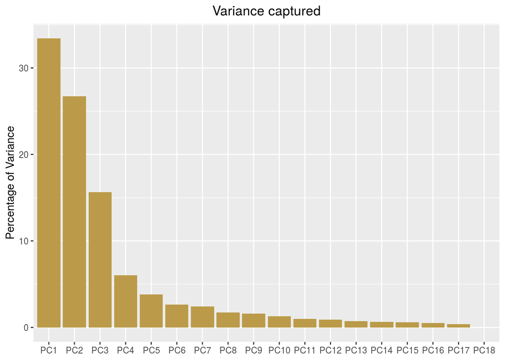

```r
var$PC <- factor(var$PC, levels = var$PC)
ggplot(data=var, aes(x=PC, y=Variance)) + geom_bar(stat="identity",fill="#bb9b49")+
  theme(axis.title.x = element_blank(),plot.title = element_text(hjust = 0.5))+labs(title = "Variance captured",y="Percentage of Variance")
```

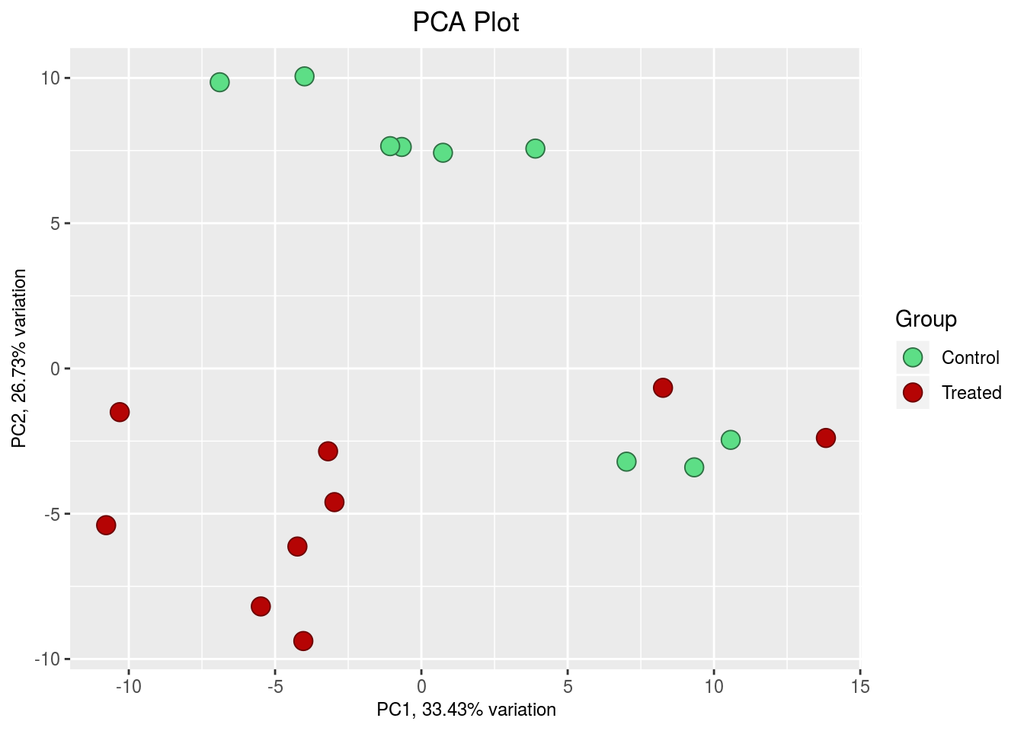

```r
ggplot(p$rotated, aes(x=PC1, y=PC2,color=Group)) + geom_point(size=4,shape=21,aes(fill=Group))+
  scale_color_manual(values=c(Treated="#6c0202",Control="#2e6f43"))+    #Outline color of the points
  scale_fill_manual(values=c(Treated="#b50404",Control="#5dde86"))+     #Fill color of the points
  theme(axis.title = element_text(size=9,hjust = 0.5),plot.title = element_text(hjust = 0.5))+
  labs(x = "PC1, 33.43% variation",y="PC2, 26.73% variation",fill="Group",color="Group",title = "PCA Plot")
```

### UMAP

UMAP is a new method for dimensionality reduction and it is now increasingly used for sample distribution visualization. (https://umap-learn.readthedocs.io/en/latest/) . After dimension reduction UMAP will give you two cordinates for each sample and then we can create scatter plot using those cordinates. Main implementation of UMAP is in Python, but there is also a R implementation (https://cran.r-project.org/web/packages/umap/index.html).

```r
#install.packages(umap)
library(umap)
data=read.delim("Input.txt",row.names = 1,check.names = FALSE)
head(data,3)
```

```
##             HC8      HC7     2HC2     HC13      HC9     2HC3     2HC1
## P35579 15.79153 15.79153 15.79153 15.79153 15.79153 15.79153 15.52392
## Q09666 15.60776 15.17471 14.80808 15.17471 15.17471 15.17471 14.80808
## Q9Y490 14.91314 15.30182 15.57128 15.30182 15.57128 15.57128 15.79408
##            HC17     HC14      VP5      VP3     VP10      VP4      VP6
## P35579 15.79153 15.79153 15.56978 15.56978 15.56978 15.77759 15.56978
## Q09666 15.90799 14.56073 14.13873 15.43381 15.43381 14.48687 15.43381
## Q9Y490 14.91314 15.57128 15.67081 14.97277 14.71204 15.49427 15.28075
##             VP8      VP9      VP2      VP7
## P35579 15.56978 15.56978 15.77759 15.56978
## Q09666 15.43381 15.43381 15.25944 15.43381
## Q9Y490 15.28075 15.28075 15.28075 14.71204
```

```r
dataX=t(data)    # Taking transpose of the data
UmapInput <- data.frame(dataX[,2:ncol(dataX)])       # Removing the sample names from the data frame.
Art.umap = umap(UmapInput)

UMAP=as.data.frame(Art.umap$layout)                  # UMAP Cordinates of the samples
head(UMAP,3)
```

```
##              V1         V2
## HC8  -1.3683013  0.0182819
## HC7  -1.6195718 -0.5885574
## 2HC2  0.8061945 -0.7756525
```

```r
names(UMAP)[1] <- "X"
names(UMAP)[2] <- "Y"
group=c(rep("Control",9),rep("Treated",9))
UMAP$Group=group
head(UMAP,3)
```

```
##               X          Y   Group
## HC8  -1.3683013  0.0182819 Control
## HC7  -1.6195718 -0.5885574 Control
## 2HC2  0.8061945 -0.7756525 Control
```

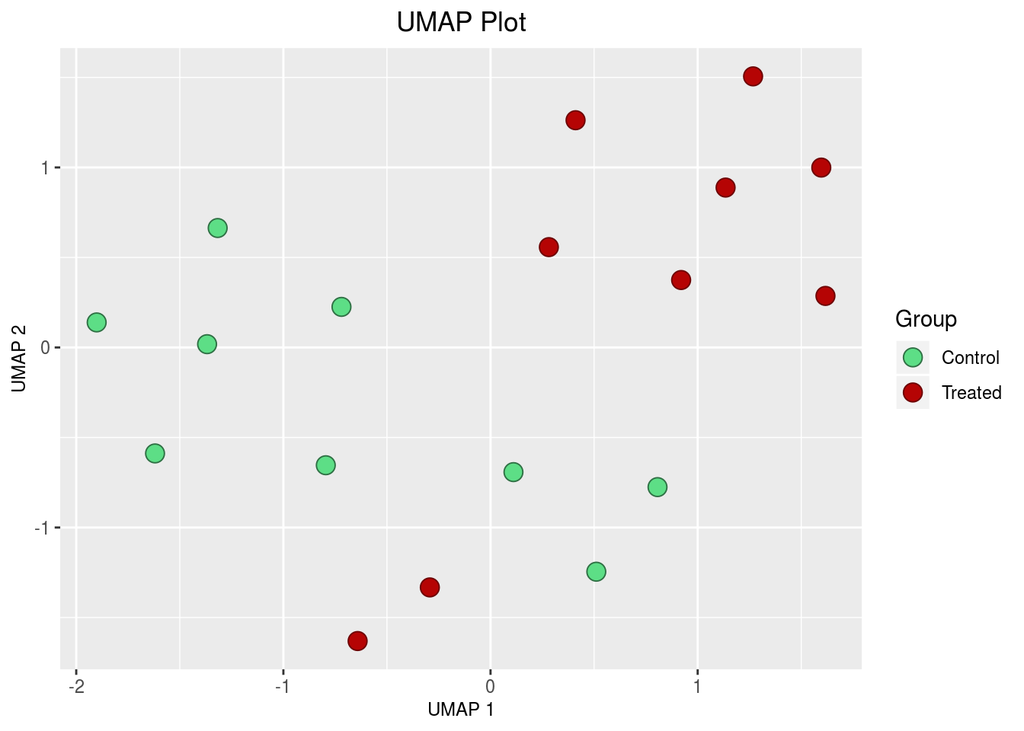

```r
ggplot(UMAP, aes(x=X, y=Y,color=Group)) + geom_point(size=4,shape=21,aes(fill=Group))+
  scale_color_manual(values=c(Treated="#6c0202",Control="#2e6f43"))+    #Outline color of the points
  scale_fill_manual(values=c(Treated="#b50404",Control="#5dde86"))+     #Fill color of the points
  theme(axis.title = element_text(size=9,hjust = 0.5),plot.title = element_text(hjust = 0.5))+
  labs(x = "UMAP 1",y="UMAP 2",fill="Group",color="Group",title = "UMAP Plot")
```